# Coalition Formation Game

Last update: 06 September, 2023

Robert Welz

welz@politik.uni-mainz.de

JGU Mainz

## The Game

- How do party goals affect coalition formation?

Let’s try it!

- We **play** several rounds of coalition formation
- Each round new (randomly drawn) party positions & election results

Expansion: Number of Parties, Multiple Dimensions, Status Quo

## Rules of the Game

- Form $x$ Groups ➜ Parties
- It’s the day after election and a new coalition has to be formed
- What’s up for grabs?
  - 1 Head of Government
  - 6 Ministerial Posts
  - Governments’ policy position

## Gameplay

- Preparation
  1. Each party secretly draws a goal (policy, office, or combined)
  2. Random draw of party positions and election results
- Gameplay
  1. Formateur (party with most seats) makes first proposal
  2. Parties take turns (in order of their seat-shares) in answering proposals or propose alternatives
  3. Parties with joined 50+X seat-share agree on a coalition

## How to win?

- Head of Government always grants **1Point**

Office- and Policy-Points depend on your party goal:

- Office-seeking: 1 point per ministerial office
- Policy-seeking: 6 - |coalition position - party position|
- Combined: $\frac{Office Points + Policy Points}{2}$

## Example

### Party Positions and Election Result

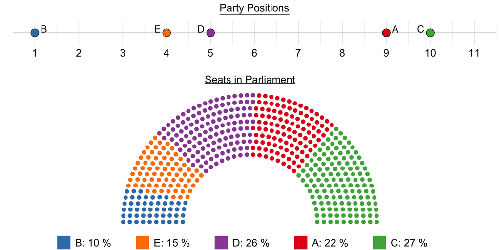

### Result

Parties D, E , and B agree on forming a coalition

- Head of Government: Party D
- Portfolios:
  - Party D: 4
  - Party E: 1
  - Party B: 1
- Policy: 3.5
  - DIstance D: 1.5
  - Distance E: 0.5
  - Distance B: 2.5

### Points

[output not shown]